# Data_Science_Project_Credit_Card_ Approval_ Prediction

Context

Download the data

The purpose of this project

Main findings

Importing packages and reading file

Data wrangling

Exploratory data analysis

Model estimation and prediction

- Data Preparation for modeling
- Estimation and prediction
- Hyperparameter tuning

Model selection and final results

Basic steps to curb imbalance in data

# Context

When banks want to figure out who should get a credit card, they use a tool called a credit score. They take a look at your personal information to see how good you might be at paying back your debts. It's like a report card for your borrowing habits. This helps them decide if lending money to you is a smart choice, making sure they don't take on too much risk.

# Download the data

https://www.kaggle.com/datasets/rikdifos/credit-card-approval-prediction/data

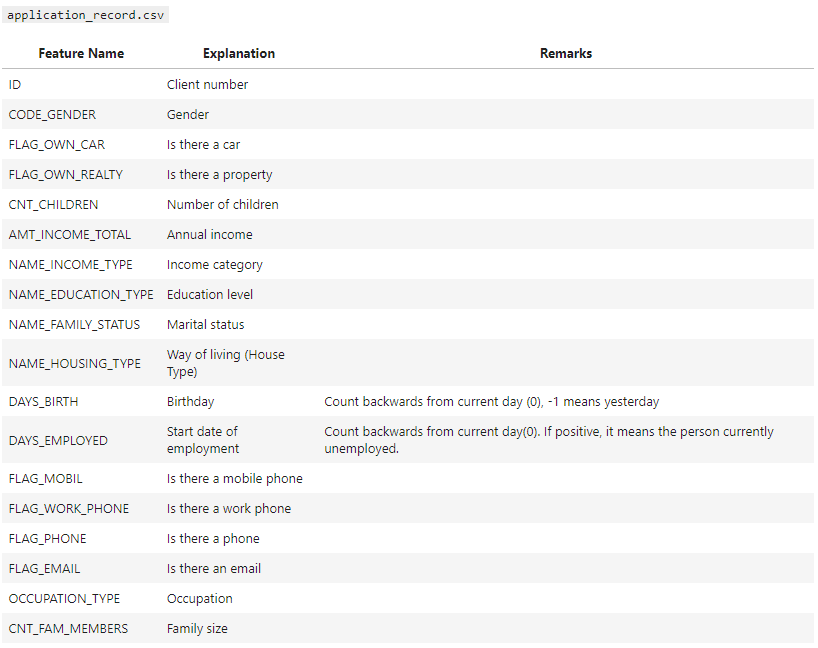

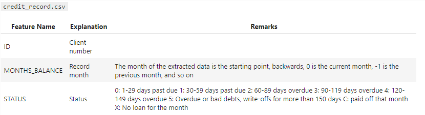

# The purpose of this project:

Building machine learning models assists banks in making informed decisions about credit card eligibility, enhancing their ability to identify suitable applicants.

# Main findings:

- Roughly two-thirds of the dataset entries are from female individuals.
- Both genders of clients own more properties than they do not.
- The majority of both female and male clients fall under the categories of `Working`, `Secondary/secondary special`, `Married`, `House/apartment`.
- The age distribution data shows that the largest segments are within the 24 to 44 years age range, peaking at 15.1% for the 34 to 39 years bracket, with a steady decline as age increases.
- The work experience data reveals that a majority of observations, specifically over 53.5%, fall within the first 5 years of experience, followed by a substantial decrease in frequency with each subsequent experience bracket.
- Among the dataset, most applicants fall within the income range of 110,000 to 140,000 (currency unknown), constituting over 24.6% of the total observations.
- Random forest and XGBoost perform relatively well in prediction and have similar performance; however, the predictive power of these models is not particularly high.
- According to the information value, most of the variables are not useful for prediction.
- It is evident that the dataset is significantly imbalanced, necessitating further data collection and additional techniques to overcome problems caused by imbalanced datasets.

# Import packages and read file

```python
# Import necessary packages
import time
import warnings
import matplotlib.pyplot as plt
import numpy as np
import pandas as pd
import scipy.stats as stats
import seaborn as sns
import statsmodels.api as sm

from sklearn.model_selection import train_test_split, GridSearchCV
from sklearn.preprocessing import RobustScaler,StandardScaler,MinMaxScaler
from sklearn import metrics
from sklearn.linear_model import LogisticRegression
from sklearn.neighbors import KNeighborsClassifier
from sklearn.tree import DecisionTreeClassifier
from sklearn.ensemble import RandomForestClassifier
from sklearn.neural_network import MLPClassifier
from sklearn.svm import SVC
from xgboost import XGBClassifier
from catboost import CatBoostClassifier
from lightgbm import LGBMClassifier

warnings.filterwarnings("ignore")
```

```python
# Read the csv file downloaded from the website
raw_data_part1 = pd.read_csv("application_record.csv")
raw_data_part2 = pd.read_csv("credit_record.csv")
```

```python
# Summary of the raw_data_part1
raw_data_part1.info()
```

```
<class 'pandas.core.frame.DataFrame'>
RangeIndex: 438557 entries, 0 to 438556
Data columns (total 18 columns):
 #   Column               Non-Null Count   Dtype
---  ------               --------------   -----
 0   ID                   438557 non-null  int64
 1   CODE_GENDER          438557 non-null  object
 2   FLAG_OWN_CAR         438557 non-null  object
 3   FLAG_OWN_REALTY      438557 non-null  object
 4   CNT_CHILDREN         438557 non-null  int64
 5   AMT_INCOME_TOTAL     438557 non-null  float64
 6   NAME_INCOME_TYPE     438557 non-null  object
 7   NAME_EDUCATION_TYPE  438557 non-null  object
 8   NAME_FAMILY_STATUS   438557 non-null  object
 9   NAME_HOUSING_TYPE    438557 non-null  object
 10  DAYS_BIRTH           438557 non-null  int64
 11  DAYS_EMPLOYED        438557 non-null  int64
 12  FLAG_MOBIL           438557 non-null  int64
 13  FLAG_WORK_PHONE      438557 non-null  int64
 14  FLAG_PHONE           438557 non-null  int64
 15  FLAG_EMAIL           438557 non-null  int64
 16  OCCUPATION_TYPE      304354 non-null  object
 17  CNT_FAM_MEMBERS      438557 non-null  float64
dtypes: float64(2), int64(8), object(8)
memory usage: 60.2+ MB
```

```python
# Summary of the raw_data_part2
raw_data_part2.info()
```

```
<class 'pandas.core.frame.DataFrame'>
RangeIndex: 1048575 entries, 0 to 1048574
Data columns (total 3 columns):
 #   Column          Non-Null Count    Dtype
---  ------          --------------    -----
 0   ID              1048575 non-null  int64
 1   MONTHS_BALANCE  1048575 non-null  int64
 2   STATUS          1048575 non-null  object
dtypes: int64(2), object(1)
memory usage: 24.0+ MB
```

**This project aims to assess the potential default risk for credit card applications, so the initial information provided by applicants is very important.**

**According to the Bank for International Settlements (BIS), the definition of default includes any assets that are more than 90 days past due; however, some financial institutions have reduced this threshold to 60 days, and this standard will be applied here.**

```python
# The clients who have not paid within 59 days at least once.
raw_data_part2["default"] = 0
raw_data_part2.loc[raw_data_part2["STATUS"].isin(["2", "3", "4", "5"]), ["default"]] = 1
raw_data_part2["default"] = raw_data_part2.groupby("ID")["default"].transform("sum")
raw_data_part2.loc[raw_data_part2["default"] > 0, ["default"]] = 1

# Merge two datasets based on ID
raw_data = pd.merge(raw_data_part1, raw_data_part2, on="ID", how="inner")

# Initial information provided by applications
data = raw_data.loc[raw_data.groupby("ID")["MONTHS_BALANCE"].idxmin()].reset_index(drop=True)
```

```python
# Summary of the data
data.info()
```

```
<class 'pandas.core.frame.DataFrame'>
RangeIndex: 36457 entries, 0 to 36456
Data columns (total 21 columns):
 #   Column               Non-Null Count  Dtype
---  ------               --------------  -----
 0   ID                   36457 non-null  int64
 1   CODE_GENDER          36457 non-null  object
 2   FLAG_OWN_CAR         36457 non-null  object
 3   FLAG_OWN_REALTY      36457 non-null  object
 4   CNT_CHILDREN         36457 non-null  int64
 5   AMT_INCOME_TOTAL     36457 non-null  float64
 6   NAME_INCOME_TYPE     36457 non-null  object
 7   NAME_EDUCATION_TYPE  36457 non-null  object
 8   NAME_FAMILY_STATUS   36457 non-null  object
 9   NAME_HOUSING_TYPE    36457 non-null  object
 10  DAYS_BIRTH           36457 non-null  int64
 11  DAYS_EMPLOYED        36457 non-null  int64
 12  FLAG_MOBIL           36457 non-null  int64
 13  FLAG_WORK_PHONE      36457 non-null  int64
 14  FLAG_PHONE           36457 non-null  int64
 15  FLAG_EMAIL           36457 non-null  int64
 16  OCCUPATION_TYPE      25134 non-null  object
 17  CNT_FAM_MEMBERS      36457 non-null  float64
 18  MONTHS_BALANCE       36457 non-null  int64
 19  STATUS               36457 non-null  object
 20  default              36457 non-null  int64
dtypes: float64(2), int64(10), object(9)
memory usage: 5.8+ MB
```

# Data wrangling

```python
# Raw data overview
data.head()
```

|  | ID | CODE_GENDER | FLAG_OWN_CAR | FLAG_OWN_REALTY | CNT_CHILDREN | AMT_INCOME_TOTAL | NAME_INCOME_TYPE | NAME_EDUCATION_TYPE | NAME_FAMILY_STATUS | NAME_HOUSING_TYPE | ... | DAYS_EMPLOYED | FLAG_MOBIL | FLAG_WORK_PHONE | FLAG_PHONE | FLAG_EMAIL | OCCUPATION_TYPE | CNT_FAM_MEMBERS | MONTHS_BALANCE | STATUS | default |
| --- | --- | --- | --- | --- | --- | --- | --- | --- | --- | --- | --- | --- | --- | --- | --- | --- | --- | --- | --- | --- | --- |
| 0 | 5008804 | M | Y | Y | 0 | 427500.0 | Working | Higher education | Civil marriage | Rented apartment | ... | -4542 | 1 | 1 | 0 | 0 | NaN | 2.0 | -15 | X | 0 |
| 1 | 5008805 | M | Y | Y | 0 | 427500.0 | Working | Higher education | Civil marriage | Rented apartment | ... | -4542 | 1 | 1 | 0 | 0 | NaN | 2.0 | -14 | X | 0 |
| 2 | 5008806 | M | Y | Y | 0 | 112500.0 | Working | Secondary / secondary special | Married | House / apartment | ... | -1134 | 1 | 0 | 0 | 0 | Security staff | 2.0 | -29 | X | 0 |
| 3 | 5008808 | F | N | Y | 0 | 270000.0 | Commercial associate | Secondary / secondary special | Single / not married | House / apartment | ... | -3051 | 1 | 0 | 1 | 1 | Sales staff | 1.0 | -4 | X | 0 |
| 4 | 5008809 | F | N | Y | 0 | 270000.0 | Commercial associate | Secondary / secondary special | Single / not married | House / apartment | ... | -3051 | 1 | 0 | 1 | 1 | Sales staff | 1.0 | -26 | X | 0 |

5 rows × 21 columns

```python
# Show the size of the data and check duplicate rows
[rowCount, coloumCount] = data.shape
print(f"the number of rows: {rowCount}")
print(f"the number of columns: {coloumCount}")
print(f"the number of duplicate rows: {raw_data.duplicated().sum()}")
```

```
the number of rows: 36457
the number of columns: 21
the number of duplicate rows: 0
```

```python
# Count the missing values and calculate the percentage
missingDetail = pd.DataFrame({"missing_count": data.isna().sum()})
missingDetail["missing_%"] = (missingDetail["missing_count"] / rowCount) * 100
print(missingDetail)
```

```
                     missing_count  missing_%
ID                               0   0.000000
CODE_GENDER                      0   0.000000
FLAG_OWN_CAR                     0   0.000000
FLAG_OWN_REALTY                  0   0.000000
CNT_CHILDREN                     0   0.000000
AMT_INCOME_TOTAL                 0   0.000000
NAME_INCOME_TYPE                 0   0.000000
NAME_EDUCATION_TYPE              0   0.000000
NAME_FAMILY_STATUS               0   0.000000
NAME_HOUSING_TYPE                0   0.000000
DAYS_BIRTH                       0   0.000000
DAYS_EMPLOYED                    0   0.000000
FLAG_MOBIL                       0   0.000000
FLAG_WORK_PHONE                  0   0.000000
FLAG_PHONE                       0   0.000000
FLAG_EMAIL                       0   0.000000
OCCUPATION_TYPE              11323  31.058507
CNT_FAM_MEMBERS                  0   0.000000
MONTHS_BALANCE                   0   0.000000
STATUS                           0   0.000000
default                          0   0.000000
```

*Main Findings:*

- There are about 31% of missing values in the variable `OCCUPATION_TYPE`.

```python
# Explore missing values in `OCCUPATION_TYPE`
data[data["OCCUPATION_TYPE"].isna()]
```

|  | ID | CODE_GENDER | FLAG_OWN_CAR | FLAG_OWN_REALTY | CNT_CHILDREN | AMT_INCOME_TOTAL | NAME_INCOME_TYPE | NAME_EDUCATION_TYPE | NAME_FAMILY_STATUS | NAME_HOUSING_TYPE | ... | DAYS_EMPLOYED | FLAG_MOBIL | FLAG_WORK_PHONE | FLAG_PHONE | FLAG_EMAIL | OCCUPATION_TYPE | CNT_FAM_MEMBERS | MONTHS_BALANCE | STATUS | default |
| --- | --- | --- | --- | --- | --- | --- | --- | --- | --- | --- | --- | --- | --- | --- | --- | --- | --- | --- | --- | --- | --- |
| 0 | 5008804 | M | Y | Y | 0 | 427500.0 | Working | Higher education | Civil marriage | Rented apartment | ... | -4542 | 1 | 1 | 0 | 0 | NaN | 2.0 | -15 | X | 0 |
| 1 | 5008805 | M | Y | Y | 0 | 427500.0 | Working | Higher education | Civil marriage | Rented apartment | ... | -4542 | 1 | 1 | 0 | 0 | NaN | 2.0 | -14 | X | 0 |
| 7 | 5008812 | F | N | Y | 0 | 283500.0 | Pensioner | Higher education | Separated | House / apartment | ... | 365243 | 1 | 0 | 0 | 0 | NaN | 1.0 | -20 | X | 0 |
| 8 | 5008813 | F | N | Y | 0 | 283500.0 | Pensioner | Higher education | Separated | House / apartment | ... | 365243 | 1 | 0 | 0 | 0 | NaN | 1.0 | -16 | X | 0 |
| 9 | 5008814 | F | N | Y | 0 | 283500.0 | Pensioner | Higher education | Separated | House / apartment | ... | 365243 | 1 | 0 | 0 | 0 | NaN | 1.0 | -17 | X | 0 |
| ... | ... | ... | ... | ... | ... | ... | ... | ... | ... | ... | ... | ... | ... | ... | ... | ... | ... | ... | ... | ... | ... |
| 36429 | 5150420 | F | N | Y | 0 | 67500.0 | Pensioner | Secondary / secondary special | Widow | House / apartment | ... | 365243 | 1 | 0 | 0 | 0 | NaN | 1.0 | -29 | 0 | 0 |
| 36430 | 5150421 | F | N | Y | 0 | 67500.0 | Pensioner | Secondary / secondary special | Widow | House / apartment | ... | 365243 | 1 | 0 | 0 | 0 | NaN | 1.0 | -27 | 0 | 0 |
| 36431 | 5150422 | F | N | Y | 0 | 67500.0 | Pensioner | Secondary / secondary special | Widow | House / apartment | ... | 365243 | 1 | 0 | 0 | 0 | NaN | 1.0 | -25 | X | 0 |
| 36432 | 5150423 | F | N | Y | 0 | 67500.0 | Pensioner | Secondary / secondary special | Widow | House / apartment | ... | 365243 | 1 | 0 | 0 | 0 | NaN | 1.0 | -12 | 0 | 0 |
| 36449 | 5150479 | F | N | N | 0 | 90000.0 | Working | Higher education | Married | With parents | ... | -128 | 1 | 0 | 0 | 0 | NaN | 2.0 | -8 | X | 0 |

11323 rows × 21 columns

*Main Findings:*

- The rows corresponding to missing values in the `OCCUPATION_TYPE` may contain useful information from other variables, so we should not remove these rows.
- We need to drop `OCCUPATION_TYPE` due to the excessive number of missing values.

```python
# Drop the variable
data.drop(["OCCUPATION_TYPE"], axis=1, inplace=True)
data.info()
```

```
<class 'pandas.core.frame.DataFrame'>
RangeIndex: 36457 entries, 0 to 36456
Data columns (total 20 columns):
 #   Column               Non-Null Count  Dtype
---  ------               --------------  -----
 0   ID                   36457 non-null  int64
 1   CODE_GENDER          36457 non-null  object
 2   FLAG_OWN_CAR         36457 non-null  object
 3   FLAG_OWN_REALTY      36457 non-null  object
 4   CNT_CHILDREN         36457 non-null  int64
 5   AMT_INCOME_TOTAL     36457 non-null  float64
 6   NAME_INCOME_TYPE     36457 non-null  object
 7   NAME_EDUCATION_TYPE  36457 non-null  object
 8   NAME_FAMILY_STATUS   36457 non-null  object
 9   NAME_HOUSING_TYPE    36457 non-null  object
 10  DAYS_BIRTH           36457 non-null  int64
 11  DAYS_EMPLOYED        36457 non-null  int64
 12  FLAG_MOBIL           36457 non-null  int64
 13  FLAG_WORK_PHONE      36457 non-null  int64
 14  FLAG_PHONE           36457 non-null  int64
 15  FLAG_EMAIL           36457 non-null  int64
 16  CNT_FAM_MEMBERS      36457 non-null  float64
 17  MONTHS_BALANCE       36457 non-null  int64
 18  STATUS               36457 non-null  object
 19  default              36457 non-null  int64
dtypes: float64(2), int64(10), object(8)
memory usage: 5.6+ MB
```

```python
# Rename the columns (YN:YesNo, Num:Number)
data.rename(
    columns={
        "ID": "id",
        "CODE_GENDER": "gender",
        "FLAG_OWN_CAR": "car_YN",
        "FLAG_OWN_REALTY": "property_YN",
        "CNT_CHILDREN": "children_Num",
        "AMT_INCOME_TOTAL": "income_Num",
        "NAME_INCOME_TYPE": "income_type",
        "NAME_EDUCATION_TYPE": "education_type",
        "NAME_FAMILY_STATUS": "family_type",
        "NAME_HOUSING_TYPE": "housing_type",
        "DAYS_BIRTH": "ages",
        "DAYS_EMPLOYED": "work_experience",
        "FLAG_MOBIL": "mobile_YN",
        "FLAG_WORK_PHONE": "work_phone_YN",
        "FLAG_PHONE": "phone_YN",
        "FLAG_EMAIL": "email_YN",
        "CNT_FAM_MEMBERS": "family_Num",
        "MONTHS_BALANCE": "months_balance",
        "STATUS": "status",
    },
    inplace=True,
)
```

```python
# Convert data type
data["gender"] = data["gender"].map({"F": 0, "M": 1})
data["car_YN"] = data["car_YN"].map({"N": 0, "Y": 1})
data["property_YN"] = data["property_YN"].map({"N": 0, "Y": 1})
data["family_Num"] = data["family_Num"].astype(int)
```

```python
# Adjust ages and working experience
data["ages"] = (-data["ages"] + data["months_balance"] * 30) / 365
data["work_experience"] = (-data["work_experience"] + data["months_balance"] * 30) / 365
display(data)
```

|  | id | gender | car_YN | property_YN | children_Num | income_Num | income_type | education_type | family_type | housing_type | ages | work_experience | mobile_YN | work_phone_YN | phone_YN | email_YN | family_Num | months_balance | status | default |
| --- | --- | --- | --- | --- | --- | --- | --- | --- | --- | --- | --- | --- | --- | --- | --- | --- | --- | --- | --- | --- |
| 0 | 5008804 | 1 | 1 | 1 | 0 | 427500.0 | Working | Higher education | Civil marriage | Rented apartment | 31.657534 | 11.210959 | 1 | 1 | 0 | 0 | 2 | -15 | X | 0 |
| 1 | 5008805 | 1 | 1 | 1 | 0 | 427500.0 | Working | Higher education | Civil marriage | Rented apartment | 31.739726 | 11.293151 | 1 | 1 | 0 | 0 | 2 | -14 | X | 0 |
| 2 | 5008806 | 1 | 1 | 1 | 0 | 112500.0 | Working | Secondary / secondary special | Married | House / apartment | 56.449315 | 0.723288 | 1 | 0 | 0 | 0 | 2 | -29 | X | 0 |
| 3 | 5008808 | 0 | 0 | 1 | 0 | 270000.0 | Commercial associate | Secondary / secondary special | Single / not married | House / apartment | 52.027397 | 8.030137 | 1 | 0 | 1 | 1 | 1 | -4 | X | 0 |
| 4 | 5008809 | 0 | 0 | 1 | 0 | 270000.0 | Commercial associate | Secondary / secondary special | Single / not married | House / apartment | 50.219178 | 6.221918 | 1 | 0 | 1 | 1 | 1 | -26 | X | 0 |
| ... | ... | ... | ... | ... | ... | ... | ... | ... | ... | ... | ... | ... | ... | ... | ... | ... | ... | ... | ... | ... |
| 36452 | 5150482 | 0 | 1 | 1 | 1 | 157500.0 | Working | Secondary / secondary special | Married | House / apartment | 27.309589 | 2.463014 | 1 | 0 | 0 | 0 | 3 | -28 | 0 | 0 |
| 36453 | 5150483 | 0 | 1 | 1 | 1 | 157500.0 | Working | Secondary / secondary special | Married | House / apartment | 28.213699 | 3.367123 | 1 | 0 | 0 | 0 | 3 | -17 | X | 0 |
| 36454 | 5150484 | 0 | 1 | 1 | 1 | 157500.0 | Working | Secondary / secondary special | Married | House / apartment | 28.624658 | 3.778082 | 1 | 0 | 0 | 0 | 3 | -12 | 0 | 0 |
| 36455 | 5150485 | 0 | 1 | 1 | 1 | 157500.0 | Working | Secondary / secondary special | Married | House / apartment | 29.528767 | 4.682192 | 1 | 0 | 0 | 0 | 3 | -1 | 0 | 0 |
| 36456 | 5150487 | 1 | 1 | 0 | 0 | 202500.0 | Working | Secondary / secondary special | Married | House / apartment | 50.761644 | 3.550685 | 1 | 0 | 0 | 0 | 2 | -29 | C | 0 |

36457 rows × 20 columns

# Exploratory data analysis

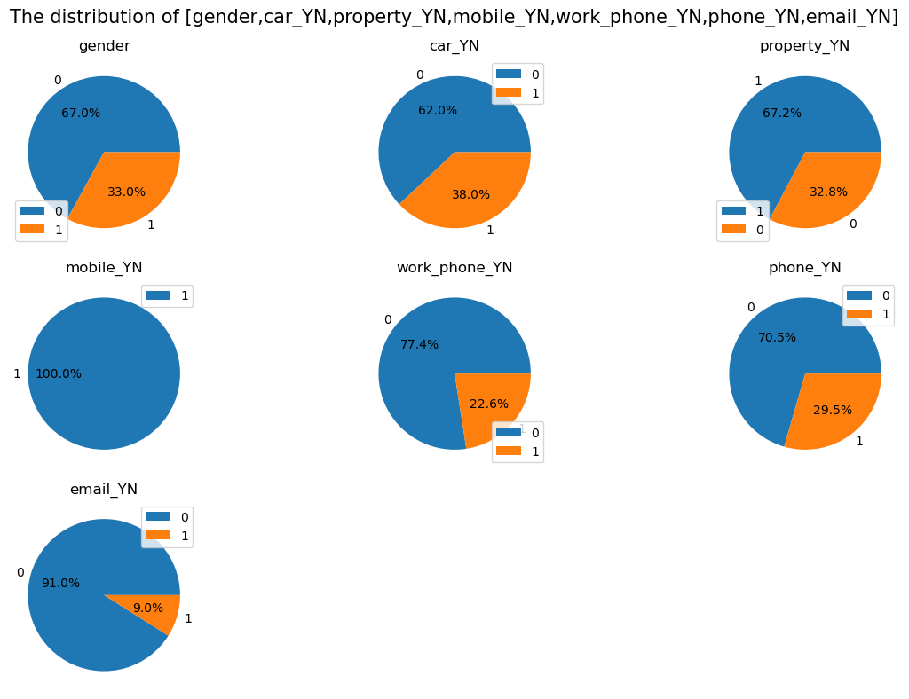

```python
# The distribution of dummy variables
binaryVariables = [
    "gender",
    "car_YN",
    "property_YN",
    "mobile_YN",
    "work_phone_YN",
    "phone_YN",
    "email_YN",
]
plt.figure(figsize=(12, 8))
plt.suptitle(
    "The distribution of [gender,car_YN,property_YN,mobile_YN,work_phone_YN,phone_YN,email_YN]",
    ha="center",
    fontsize=15,
)

for i in range(len(binaryVariables)):
    plt.subplot(3, 3, i + 1)
    plt.title(binaryVariables[i])
    counts = data[binaryVariables[i]].value_counts()
    plt.pie(counts, labels=counts.index, autopct="%1.1f%%")
    plt.legend(counts.index)
plt.tight_layout()
plt.show()
```

*Main Findings:*

- Approximately 67% of the records in the dataset are female.
- Although 67.2% of the records show that clients own a property, 62% of the records indicate that clients do not own a car.
- There are about 22.6% of the records showing that clients have a work phone.
- Only 9.0% of the records show that clients have an email address.
- We need to drop the `mobile_YN` because it contains all ones.

```python
# Drop the variable
data.drop(["mobile_YN"], axis=1, inplace=True)
```

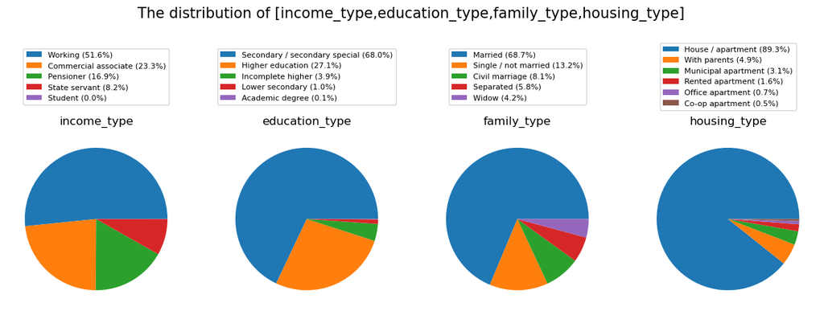

```python
# The distribution of other categorical variables
catVariables = [
    "income_type",
    "education_type",
    "family_type",
    "housing_type",
]

plt.figure(figsize=(12, 6))
plt.suptitle(
    "The distribution of [income_type,education_type,family_type,housing_type]",
    ha="center",
    fontsize=15,
)

for i in range(len(catVariables)):
    plt.subplot(1, 4, i + 1)
    plt.title(catVariables[i])
    counts = data[catVariables[i]].value_counts()
    total = sum(counts)
    percentages = [f"{100 * count / total:.1f}%" for count in counts]
    labels_with_percentages = [
        f"{label} ({percentage})"
        for label, percentage in zip(counts.index, percentages)
    ]
    plt.pie(counts)
    plt.legend(
        labels_with_percentages, loc="center", bbox_to_anchor=(0.5, 1.3), fontsize=8
    )
plt.tight_layout()
plt.show()
```

*Main Findings:*

- Approximately 51.6% of the records show that clients' income comes from `Working`.
- Approximately 68% of the records indicate that clients have completed `Secondary/secondary special` education.
- Marriage is the most common martial status in the records, at about 68.7%.
- A significant 89.3% of the records indicate that clients identify their living spaces as houses or apartments.

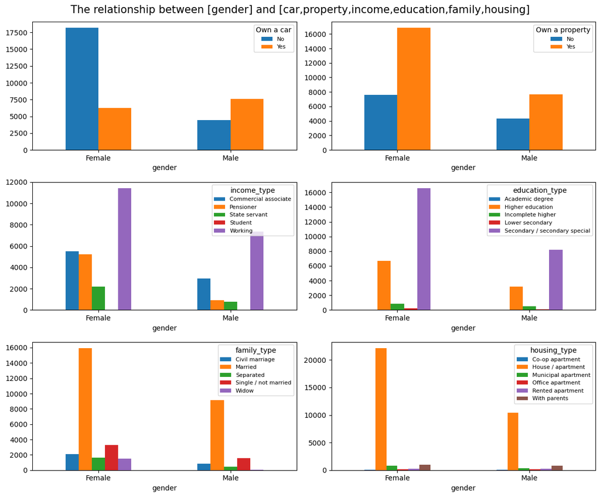

```python
# Explore the relationship between [gender] and [car,property,income,education,family,housing]

fig, axs = plt.subplots(3, 2, figsize=(12, 10))

ds_car = pd.crosstab(data["gender"], data["car_YN"])
ax = ds_car.plot.bar(ax=axs[0, 0])
ax.set_xticklabels(["Female", "Male"], rotation=0)
ax.legend(title="Own a car", labels=["No", "Yes"], loc="upper right", fontsize=8)

ds_property = pd.crosstab(data["gender"], data["property_YN"])
ax = ds_property.plot.bar(ax=axs[0, 1])
ax.set_xticklabels(["Female", "Male"], rotation=0)
ax.legend(title="Own a property", labels=["No", "Yes"], loc="upper right", fontsize=8)

ds_income = pd.crosstab(data["gender"], data["income_type"])
ax = ds_income.plot.bar(ax=axs[1, 0])
ax.set_xticklabels(["Female", "Male"], rotation=0)
ax.legend(title="income_type", labels=ds_income.columns, loc="upper right", fontsize=8)

ds_edu = pd.crosstab(data["gender"], data["education_type"])
ax = ds_edu.plot.bar(ax=axs[1, 1])
ax.set_xticklabels(["Female", "Male"], rotation=0)
ax.legend(title="education_type", labels=ds_edu.columns, loc="upper right", fontsize=8)

ds_family = pd.crosstab(data["gender"], data["family_type"])
ax = ds_family.plot.bar(ax=axs[2, 0])
ax.set_xticklabels(["Female", "Male"], rotation=0)
ax.legend(title="family_type", labels=ds_family.columns, loc="upper right", fontsize=8)

ds_house = pd.crosstab(data["gender"], data["housing_type"])
ax = ds_house.plot.bar(ax=axs[2, 1])
ax.set_xticklabels(["Female", "Male"], rotation=0)
ax.legend(title="housing_type", labels=ds_house.columns, loc="upper right", fontsize=8)

fig.suptitle(
    "The relationship between [gender] and [car,property,income,education,family,housing]",
    ha="center",
    fontsize=15,
)
plt.tight_layout()
plt.show()
```

*Main Findings:*

- In the dataset, a higher number of males own cars compared to females, and a significant portion of females do not own cars.
- Both genders of clients own more properties than they do not.
- The majority of both female and male clients fall under the categories of `Working`, `Secondary/secondary special`, `Married`, `House/apartment`.

```python
# Total defaults
data["default"].value_counts()
```

```
default
0    35841
1      616
Name: count, dtype: int64
```

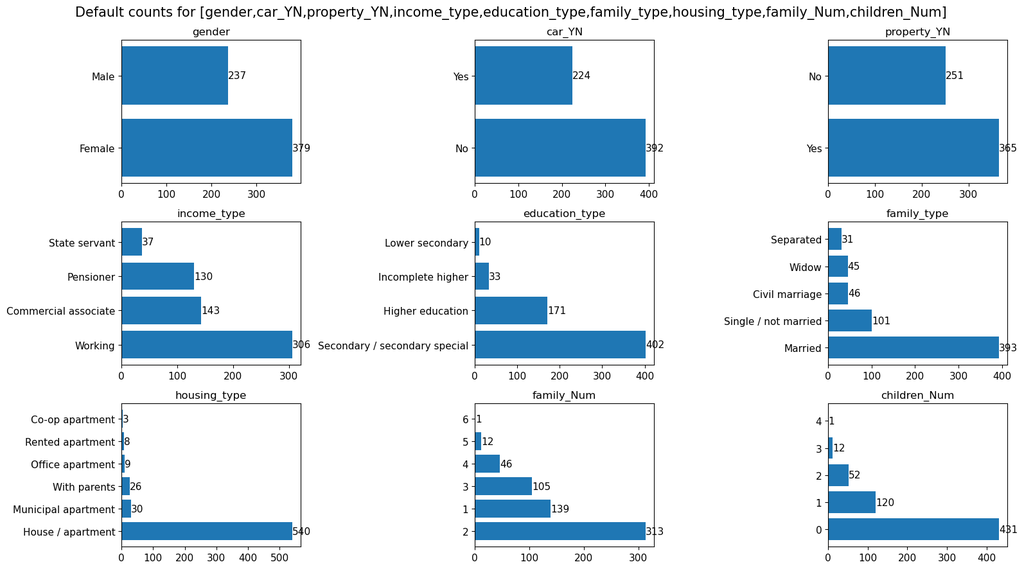

```python
# Counting defaults

theVariables = [
    "gender",
    "car_YN",
    "property_YN",
    "income_type",
    "education_type",
    "family_type",
    "housing_type",
    "family_Num",
    "children_Num",
]

ds = data.loc[data["default"] == 1, theVariables]
ds["gender"] = ds["gender"].map({0: "Female", 1: "Male"})
ds["car_YN"] = ds["car_YN"].map({0: "No", 1: "Yes"})
ds["property_YN"] = ds["property_YN"].map({0: "No", 1: "Yes"})

plt.figure(figsize=(16, 9))
plt.suptitle(
    "Default counts for [gender,car_YN,property_YN,income_type,education_type,family_type,housing_type,family_Num,children_Num]",
    ha="center",
    fontsize=15,
)

for i in range(len(theVariables)):
    plt.subplot(3, 3, i + 1)
    plt.title(theVariables[i])
    counts = ds[theVariables[i]].value_counts()
    plt.barh(counts.index.astype(str), counts.values)

    for j, (value, count) in enumerate(zip(counts.index, counts.values)):
        plt.text(count, j, f"{count}", va="center", ha="left", fontsize=11)

    plt.tick_params(axis="both", labelsize=11)
plt.tight_layout()
plt.show()
```

*Main Findings:*

- `gender`: There are 379 defaults for females and 237 for males.
- `car_YN`: There are 392 defaults for individuals without a car and 224 for those with a car.
- `property_YN`: Individuals with property have 365 defaults, and those without have 251.
- `income_type`: Working individuals have the highest count of defaults with 306, followed by commercial associates with 143, pensioners with 130, and state servants with 37.
- `education_type`: The majority of individuals who defaulted are found in the secondary or secondary special education category, totaling 402. A significant number, 171, have completed higher education.
- `family_type`: Married individuals account for the highest number of defaults at 393. In comparison, there are 101 defaults among those who are single or not married.
- `housing_type`: The majority of individuals with defaults reside in houses or apartments, numbering 540.
- `family_Num`: Families with two members have the most defaults, with 313, followed by one-member families with 139. The number of defaults decreases as family size increases.
- `children_Num`: A total of 431 individuals with defaults are without children, and defaults tend to decrease as the number of children in a family increases.

```python
# Descriptive statistics on ages and work_experience
data[["ages", "work_experience", "income_Num"]].describe()
```

|  | ages | work_experience | income_Num |
| --- | --- | --- | --- |
| count | 36457.000000 | 36457.000000 | 3.645700e+04 |
| mean | 41.617117 | -164.514689 | 1.866857e+05 |
| std | 11.515155 | 377.116790 | 1.017892e+05 |
| min | 19.030137 | -1005.597260 | 2.700000e+04 |
| 25% | 32.000000 | -1.084932 | 1.215000e+05 |
| 50% | 40.465753 | 2.219178 | 1.575000e+05 |
| 75% | 51.016438 | 6.457534 | 2.250000e+05 |
| max | 67.972603 | 41.734247 | 1.575000e+06 |

```python
print(f"The number of unemployed: {sum(data["work_experience"]<0)}")
print(f"The percentage of unemployed: {100*sum(data["work_experience"]<0)/len(data):.2f}%")
```

```
The number of unemployed: 11520
The percentage of unemployed: 31.60%
```

*Main Findings:*

- Ages ranging from 19 to 70 will be used to construct the age bins.
- Work experience ranging from 0 to 45 years will be used to construct the bins.
  - The outlier data point at -1005.597260 will not be considered.
  - A negative value signifies that an individual is currently unemployed. This group represents approximately 31.60% of the total observations. Since the work experience of these individuals is unknown, the variable will be excluded from the model.
- Income ranging from 20000 to 1580000 will be used to construct the age bins.

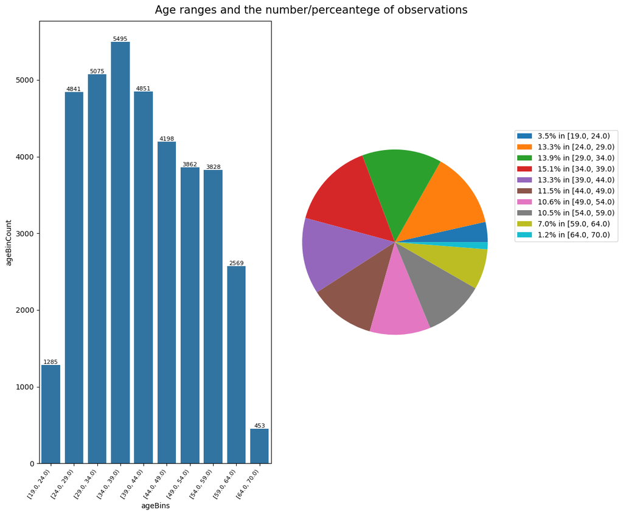

```python
## The distribution of ages
ageBins = np.arange(19, 69, 5)
ageBins = np.ceil(np.append(ageBins, 70))
data["ageBins"] = pd.cut(data["ages"], ageBins, right=False)
ageStat = (
    data.groupby("ageBins")
    .aggregate(ageBinCount=("ageBins", "count"))
    .reset_index()
)
ageStat["ageBinCount%"] = ageStat["ageBinCount"] / sum(ageStat["ageBinCount"])

[fig, axes] = plt.subplots(1, 2,figsize=(12,10))

ax = sns.barplot(ax=axes[0], data=ageStat, x="ageBins", y="ageBinCount")
ax.bar_label(ax.containers[0], fontsize=8)
axes[0].tick_params(axis="x", rotation=55, labelsize=8)

theLegend = (
    np.round(ageStat["ageBinCount%"] * 100, 1).astype(str)
    + "% in "
    + ageStat["ageBins"].astype(str)
)
axes[1].pie(ageStat["ageBinCount"])
axes[1].legend(theLegend, bbox_to_anchor=(1, 1))

plt.sca(axes[0])
plt.xticks(ha="right")
fig.suptitle(
    "Age ranges and the number/perceantege of observations",
    ha="center",
    fontsize=15,
)
plt.tight_layout()
plt.show()
```

*Main Findings:*

- The age distribution data shows that the largest segments are within the 24 to 44 years age range, peaking at 15.1% for the 34 to 39 years bracket, with a steady decline as age increases.

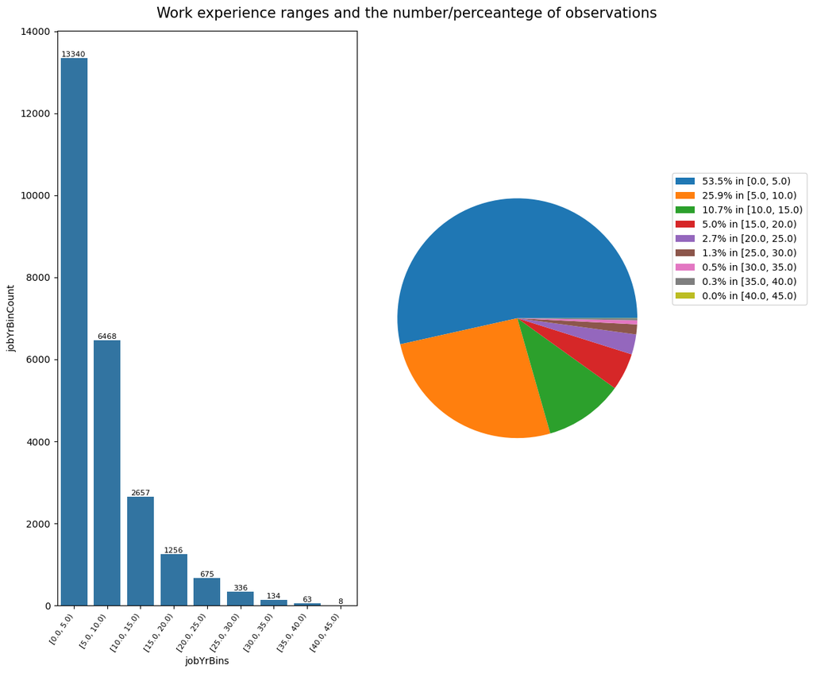

```python
# The distribution of work experience
jobYrBins = np.arange(0, 41, 5)
jobYrBins = np.ceil(np.append(jobYrBins, 45))
data["jobYrBins"] = pd.cut(data["work_experience"], jobYrBins, right=False)
jobYrStat = (
    data.groupby("jobYrBins")
    .aggregate(jobYrBinCount=("jobYrBins", "count"))
    .reset_index()
)
jobYrStat["jobYrBinCount%"] = jobYrStat["jobYrBinCount"] / sum(
    jobYrStat["jobYrBinCount"]
)

[fig, axes] = plt.subplots(1, 2, figsize=(12, 10))

ax = sns.barplot(ax=axes[0], data=jobYrStat, x="jobYrBins", y="jobYrBinCount")
ax.bar_label(ax.containers[0], fontsize=8)
axes[0].tick_params(axis="x", rotation=55, labelsize=8)

theLegend = (
    np.round(jobYrStat["jobYrBinCount%"] * 100, 1).astype(str)
    + "% in "
    + jobYrStat["jobYrBins"].astype(str)
)
axes[1].pie(jobYrStat["jobYrBinCount"])
axes[1].legend(theLegend, bbox_to_anchor=(1, 1))

plt.sca(axes[0])
plt.xticks(ha="right")
fig.suptitle(
    "Work experience ranges and the number/perceantege of observations",
    ha="center",
    fontsize=15,
)
plt.tight_layout()
plt.show()
```

*Main Findings:*

- The work experience data reveals that a majority of observations, specifically over 53.5%, fall within the first 5 years of experience, followed by a substantial decrease in frequency with each subsequent experience bracket.

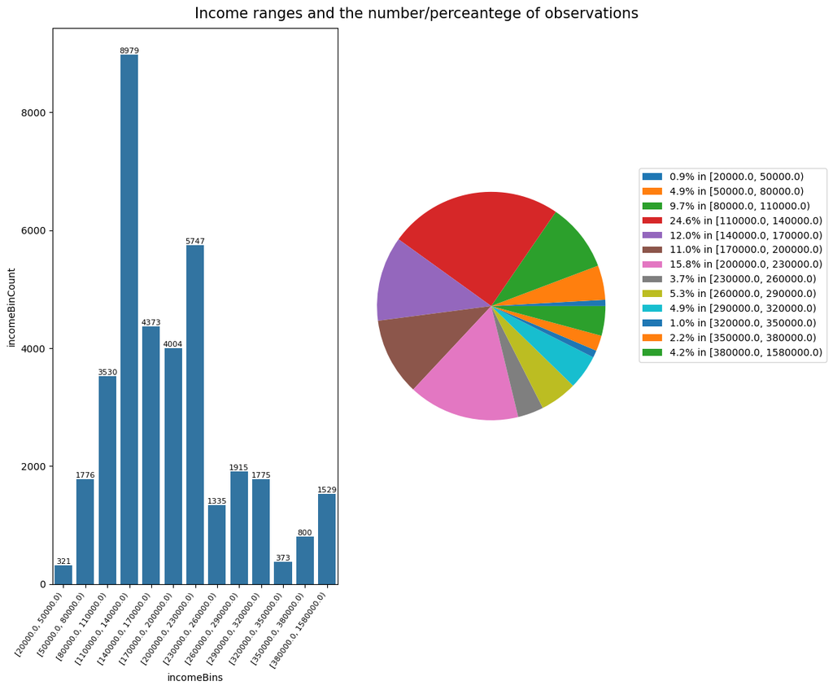

```python
# The distribution of annual income
incomeBins = np.arange(20000, 400000, 30000)
incomeBins = np.ceil(np.append(incomeBins, 1580000))
data["incomeBins"] = pd.cut(data["income_Num"], incomeBins, right=False)
incomeStat = (
    data.groupby("incomeBins")
    .aggregate(incomeBinCount=("incomeBins", "count"))
    .reset_index()
)
incomeStat["incomeBinCount%"] = incomeStat["incomeBinCount"] / sum(
    incomeStat["incomeBinCount"]
)

[fig, axes] = plt.subplots(1, 2, figsize=(12, 10))

ax = sns.barplot(ax=axes[0], data=incomeStat, x="incomeBins", y="incomeBinCount")
ax.bar_label(ax.containers[0], fontsize=8)
axes[0].tick_params(axis="x", rotation=55, labelsize=8)

theLegend = (
    np.round(incomeStat["incomeBinCount%"] * 100, 1).astype(str)
    + "% in "
    + incomeStat["incomeBins"].astype(str)
)
axes[1].pie(incomeStat["incomeBinCount"])
axes[1].legend(theLegend, bbox_to_anchor=(1, 1))

plt.sca(axes[0])
plt.xticks(ha="right")
fig.suptitle(
    "Income ranges and the number/perceantege of observations",
    ha="center",
    fontsize=15,
)
plt.tight_layout()
plt.show()
```

*Main Findings:*

- Among the dataset, most applicants fall within the income range of 110,000 to 140,000 (currency unknown), constituting over 24.6% of the total observations.

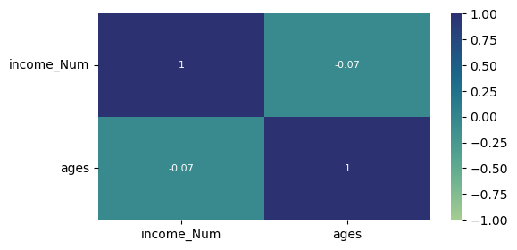

```python
# Explore the correlation between income and age
continuousVar = ["income_Num", "ages"]
corrVar = data[continuousVar]
plt.figure(figsize=(6, 3))
coef = corrVar.corr()
sns.heatmap(coef, annot=True, annot_kws={"fontsize": 8}, cmap="crest", vmin=-1, vmax=1)
plt.xticks(rotation=0, ha="center")
plt.yticks(rotation=0, ha="right")
plt.show()
```

*Main Findings:*

- The correlation between age and income is weak.

# Model estimation and prediction

## Data preparation for modeling

```python
# Drop unnecessary variables
mdlData = data.copy()
mdlData.drop(
    [
        "id",
        "work_experience",
        "ageBins",
        "jobYrBins",
        "incomeBins",
        "months_balance",
        "status",
    ],
    axis=1,
    inplace=True,
)
mdlData.columns
```

```
Index(['gender', 'car_YN', 'property_YN', 'children_Num', 'income_Num',
       'income_type', 'education_type', 'family_type', 'housing_type', 'ages',
       'work_phone_YN', 'phone_YN', 'email_YN', 'family_Num', 'default'],
      dtype='object')
```

```python
# Functions to detect outliers
def outliersNumber_IQR(vec):
    pct25 = vec.quantile(0.25)
    pct75 = vec.quantile(0.75)
    iqr = pct75 - pct25
    upperLimit = pct75 + 1.5 * iqr
    lowerLimit = pct25 - 1.5 * iqr
    outliersNumber = sum((vec > upperLimit) | (vec < lowerLimit))
    outlierIndex = vec[(vec > upperLimit) | (vec < lowerLimit)].index
    return outliersNumber, outlierIndex


def outliersNumber_Std(vec):
    upperLimit = vec.mean() + 3 * vec.std()
    lowerLimit = vec.mean() - 3 * vec.std()
    outliersNumber = sum((vec > upperLimit) | (vec < lowerLimit))
    outlierIndex = vec[(vec > upperLimit) | (vec < lowerLimit)].index
    return outliersNumber, outlierIndex
```

```python
# Count the number of outliers
outlierVar = ["children_Num", "family_Num", "income_Num", "ages"]
print("the number of outliers based on 1.5 IQR >>")
for var in outlierVar:
    [outliersNumber, _] = outliersNumber_IQR(mdlData[var])
    print(f"{var}: {outliersNumber}")
```

```
the number of outliers based on 1.5 IQR >>
children_Num: 508
family_Num: 480
income_Num: 1529
ages: 0
```

```python
# Count the number of outliers
print("the number of outliers based on 3std >>")
for var in outlierVar:
    [outliersNumber, _] = outliersNumber_Std(mdlData[var])
    print(f"{var}: {outliersNumber}")
```

```
the number of outliers based on 3std >>
children_Num: 508
family_Num: 480
income_Num: 518
ages: 0
```

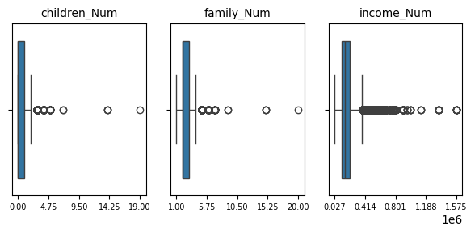

```python
# Boxplot on the variables
outlierVar = ["children_Num", "family_Num", "income_Num", "ages"]

numericData = mdlData[outlierVar].copy()
[fig, axes] = plt.subplots(1, 3, figsize=(6, 3))
for val, axe in zip(outlierVar, axes.flat):
    sns.boxplot(ax=axe, data=numericData, x=val)
    axe.set_title(val, fontsize=10)
    axe.set_xlabel("")
    axe.set_xticks(np.linspace(min(numericData[val]), max(numericData[val]), 5))
    axe.tick_params(axis="both", labelsize=7)
fig.tight_layout()
```

```python
# From a conservative standpoint, the rule for deleting outliers is not based on the 1.5IQR or 3Std here.
# Outliers in the `children_Num` variable
print(mdlData["children_Num"].value_counts())

# Defaults in children_Num>=5
children_Num5_Default = (
    (mdlData["children_Num"] >= 5) & (mdlData["default"] == 1)
).sum()

print("------------------------------------------------------")
print(f"Defaults in children_Num >= 5: {children_Num5_Default}")
print(
    f"With {children_Num5_Default} defaults among the outliers, outliers can be removed without significant impact."
)
print("------------------------------------------------------")

# Observations with children_num >= 5 are deleted
mdlData = mdlData[mdlData["children_Num"] <= 4]
print(mdlData["children_Num"].value_counts())
```

```
children_Num
0     25201
1      7492
2      3256
3       419
4        63
5        20
14        3
7         2
19        1
Name: count, dtype: int64
------------------------------------------------------
Defaults in children_Num >= 5: 0
With 0 defaults among the outliers, outliers can be removed without significant impact.
------------------------------------------------------
children_Num
0    25201
1     7492
2     3256
3      419
4       63
Name: count, dtype: int64
```

```python
# Print `family_Num` variable (Some outliers have been removed in the last step)
print(mdlData["family_Num"].value_counts())
```

```
family_Num
2    19463
1     6987
3     6421
4     3106
5      397
6       57
Name: count, dtype: int64
```

```python
# Outliers in the `income_Num` variable
[numIQR, idxIQR] = outliersNumber_IQR(mdlData["income_Num"])
[numStd, idxStd] = outliersNumber_Std(mdlData["income_Num"])
print("outliers based on 1.5 IQR threshold:")
print(mdlData.loc[idxIQR, "income_Num"].sort_values())
print("")
print("outliers based on 3std threshold:")
print(mdlData.loc[idxStd, "income_Num"].sort_values())
```

```
outliers based on 1.5 IQR threshold:
30487     382500.0
26735     382500.0
10535     382500.0
21169     382500.0
8566      382500.0
           ...
34061    1575000.0
34060    1575000.0
34059    1575000.0
34058    1575000.0
34057    1575000.0
Name: income_Num, Length: 1529, dtype: float64

outliers based on 3std threshold:
34698     494100.0
34695     494100.0
34696     494100.0
34697     494100.0
18035     495000.0
           ...
34060    1575000.0
34059    1575000.0
34058    1575000.0
34057    1575000.0
34056    1575000.0
Name: income_Num, Length: 518, dtype: float64
```

```python
# The rule for deleting outliers is based on the 3Std here.
# Defaults in very high earners
highIncomeDefault = (
    (mdlData["income_Num"] >= 494100.0) & (mdlData["default"] == 1)
).sum()
print(f"Defaults in Very High Earners(3Std above): {highIncomeDefault}")

# Delete observations with outliers
mdlData.drop(idxStd, axis=0, inplace=True)
```

```
Defaults in Very High Earners(3Std above): 7
```

```python
# Total defaults
print(mdlData["default"].value_counts())
print(mdlData["default"].value_counts(normalize=True))
```

```
default
0    35304
1      609
Name: count, dtype: int64
default
0    0.983042
1    0.016958
Name: proportion, dtype: float64
```

*Main Findings:*

- With only 7 defaults among the outliers, outliers can be removed without significant impact.
- Finally, total number of defaults in the model data is 609 (1.7%).

```python
# Functions to convert categorical variables to dummy variables
def categorical_to_dummy(mdlData, feature):
    tempDs = pd.get_dummies(mdlData[feature], prefix=feature).astype(int)
    # drop dummy with lowest frequency
    dropDum = f"{feature}_{mdlData[feature].value_counts().index[-1]}"
    tempDs.drop([dropDum], axis=1, inplace=True)
    return tempDs
```

```python
# Convert categorical variable into dummy variables
categoricalVar = [
    "income_type",
    "education_type",
    "family_type",
    "housing_type",
]
mdlDataFull = mdlData.loc[
    :,
    [
        "gender",
        "car_YN",
        "property_YN",
        "income_Num",
        "ages",
        "work_phone_YN",
        "phone_YN",
        "email_YN",
        "children_Num",
        "family_Num",
        "default",
    ],
]
for feature in categoricalVar:
    ds = categorical_to_dummy(mdlData, feature)
    mdlDataFull = mdlDataFull.join(ds)
```

```python
# Summary of the full model data
pd.set_option("display.max_columns", None)
mdlDataFull.reset_index(drop=True, inplace=True)
mdlDataFull.info()
mdlDataFull.describe()
```

```
<class 'pandas.core.frame.DataFrame'>
RangeIndex: 35913 entries, 0 to 35912
Data columns (total 28 columns):
 #   Column                                        Non-Null Count  Dtype
---  ------                                        --------------  -----
 0   gender                                        35913 non-null  int64
 1   car_YN                                        35913 non-null  int64
 2   property_YN                                   35913 non-null  int64
 3   income_Num                                    35913 non-null  float64
 4   ages                                          35913 non-null  float64
 5   work_phone_YN                                 35913 non-null  int64
 6   phone_YN                                      35913 non-null  int64
 7   email_YN                                      35913 non-null  int64
 8   children_Num                                  35913 non-null  int64
 9   family_Num                                    35913 non-null  int32
```

[output cut: 20 more lines]

|  | gender | car_YN | property_YN | income_Num | ages | work_phone_YN | phone_YN | email_YN | children_Num | family_Num | default | income_type_Commercial associate | income_type_Pensioner | income_type_State servant | income_type_Working | education_type_Higher education | education_type_Incomplete higher | education_type_Lower secondary | education_type_Secondary / secondary special | family_type_Civil marriage | family_type_Married | family_type_Separated | family_type_Single / not married | housing_type_House / apartment | housing_type_Municipal apartment | housing_type_Office apartment | housing_type_Rented apartment | housing_type_With parents |
| --- | --- | --- | --- | --- | --- | --- | --- | --- | --- | --- | --- | --- | --- | --- | --- | --- | --- | --- | --- | --- | --- | --- | --- | --- | --- | --- | --- | --- |
| count | 35913.000000 | 35913.000000 | 35913.000000 | 35913.000000 | 35913.000000 | 35913.000000 | 35913.000000 | 35913.000000 | 35913.000000 | 35913.000000 | 35913.000000 | 35913.000000 | 35913.000000 | 35913.000000 | 35913.000000 | 35913.000000 | 35913.000000 | 35913.000000 | 35913.000000 | 35913.000000 | 35913.000000 | 35913.000000 | 35913.000000 | 35913.00000 | 35913.000000 | 35913.000000 | 35913.000000 | 35913.000000 |
| mean | 0.327542 | 0.376187 | 0.670342 | 179756.198438 | 41.615705 | 0.225712 | 0.293042 | 0.088297 | 0.423858 | 2.192354 | 0.016958 | 0.229889 | 0.170523 | 0.081503 | 0.517779 | 0.266255 | 0.038315 | 0.010414 | 0.684126 | 0.081335 | 0.686854 | 0.057305 | 0.132097 | 0.89288 | 0.031103 | 0.007100 | 0.015649 | 0.049007 |
| std | 0.469323 | 0.484435 | 0.470095 | 81579.539123 | 11.547792 | 0.418056 | 0.455164 | 0.283730 | 0.715368 | 0.890928 | 0.129114 | 0.420767 | 0.376097 | 0.273609 | 0.499691 | 0.442005 | 0.191958 | 0.101518 | 0.464870 | 0.273353 | 0.463780 | 0.232428 | 0.338601 | 0.30927 | 0.173598 | 0.083966 | 0.124115 | 0.215886 |
| min | 0.000000 | 0.000000 | 0.000000 | 27000.000000 | 19.030137 | 0.000000 | 0.000000 | 0.000000 | 0.000000 | 1.000000 | 0.000000 | 0.000000 | 0.000000 | 0.000000 | 0.000000 | 0.000000 | 0.000000 | 0.000000 | 0.000000 | 0.000000 | 0.000000 | 0.000000 | 0.000000 | 0.00000 | 0.000000 | 0.000000 | 0.000000 | 0.000000 |
| 25% | 0.000000 | 0.000000 | 0.000000 | 121500.000000 | 31.928767 | 0.000000 | 0.000000 | 0.000000 | 0.000000 | 2.000000 | 0.000000 | 0.000000 | 0.000000 | 0.000000 | 0.000000 | 0.000000 | 0.000000 | 0.000000 | 0.000000 | 0.000000 | 0.000000 | 0.000000 | 0.000000 | 1.00000 | 0.000000 | 0.000000 | 0.000000 | 0.000000 |
| 50% | 0.000000 | 0.000000 | 1.000000 | 157500.000000 | 40.446575 | 0.000000 | 0.000000 | 0.000000 | 0.000000 | 2.000000 | 0.000000 | 0.000000 | 0.000000 | 0.000000 | 1.000000 | 0.000000 | 0.000000 | 0.000000 | 1.000000 | 0.000000 | 1.000000 | 0.000000 | 0.000000 | 1.00000 | 0.000000 | 0.000000 | 0.000000 | 0.000000 |
| 75% | 1.000000 | 1.000000 | 1.000000 | 225000.000000 | 51.068493 | 0.000000 | 1.000000 | 0.000000 | 1.000000 | 3.000000 | 0.000000 | 0.000000 | 0.000000 | 0.000000 | 1.000000 | 1.000000 | 0.000000 | 0.000000 | 1.000000 | 0.000000 | 1.000000 | 0.000000 | 0.000000 | 1.00000 | 0.000000 | 0.000000 | 0.000000 | 0.000000 |
| max | 1.000000 | 1.000000 | 1.000000 | 472500.000000 | 67.972603 | 1.000000 | 1.000000 | 1.000000 | 4.000000 | 6.000000 | 1.000000 | 1.000000 | 1.000000 | 1.000000 | 1.000000 | 1.000000 | 1.000000 | 1.000000 | 1.000000 | 1.000000 | 1.000000 | 1.000000 | 1.000000 | 1.00000 | 1.000000 | 1.000000 | 1.000000 | 1.000000 |

## Estimation and prediction

```python
# Split the data into training and testing sets
X = mdlDataFull.drop(["default"], axis=1)
y = mdlDataFull["default"]
[X_train, X_test, y_train, y_test] = train_test_split(
    X, y, test_size=0.3, shuffle=True, stratify=y, random_state=8
)

X_train.loc[:, ["income_Num"]] = np.log(X_train.loc[:, ["income_Num"]])
X_test.loc[:, ["income_Num"]] = np.log(X_test.loc[:, ["income_Num"]])

# Get shape of each training and testing set
X_train.shape, X_test.shape, y_train.shape, y_test.shape
```

```
((25139, 27), (10774, 27), (25139,), (10774,))
```

```python
# Build the models
models = [
    ("logitReg", LogisticRegression()),
    ("SVM", SVC(random_state=8)),
    ("KNN", KNeighborsClassifier()),
    ("dTree", DecisionTreeClassifier(random_state=8)),
    ("rForest", RandomForestClassifier(n_jobs=-1, random_state=8)),
    ("NN", MLPClassifier(random_state=8)),
    ("XGBoost", XGBClassifier()),
    ("CatBoost", CatBoostClassifier(random_seed=8, verbose=False)),
    ("LightGBM", LGBMClassifier(verbose=-1)),
]
```

```python
# Function to evaluate models
def modelEvaluation(models, X_train=None, y_train=None, X_test=None, y_test=None):
    resultTable = {}
    predValue = {}

    for modelName, model in models:
        timeBeg = time.time()
        model.fit(X_train, y_train)
        y_pred = model.predict(X_test)
        f1 = metrics.f1_score(y_test, y_pred)
        precision = metrics.precision_score(y_test, y_pred)
        recall = metrics.recall_score(y_test, y_pred)
        timeDur = time.time() - timeBeg

        resultTable.update({modelName: [f1, precision, recall, timeDur]})
        predValue.update({modelName: y_pred})

    resultTable = pd.DataFrame(resultTable)
    resultTable.index = ["f1_score", "precision", "recall", "model_time"]
    predValue = pd.DataFrame(predValue)
    predValue["actual"] = y_test.reset_index(drop=True)

    print("models performance >>")
    display(resultTable.head())
    print("")
    print("predictions overview >>")
    display(predValue.head())

    return resultTable, predValue
```

```python
# Function to visualize models performance
def modelVisualization(resultTable):
    modelNames = resultTable.columns
    [fig, axes] = plt.subplots(2, 2, figsize=(12, 6))

    axes[0, 0].bar(modelNames, resultTable.loc["f1_score"])
    axes[0, 0].set_title("f1_score")
    plt.sca(axes[0, 0])  # Set the current axis
    plt.xticks(rotation=30)

    axes[0, 1].bar(modelNames, resultTable.loc["precision"])
    axes[0, 1].set_title("precision")
    plt.sca(axes[0, 1])  # Set the current axis
    plt.xticks(rotation=30)

    axes[1, 0].bar(modelNames, resultTable.loc["recall"])
    axes[1, 0].set_title("recall")
    plt.sca(axes[1, 0])  # Set the current axis
    plt.xticks(rotation=30)

    axes[1, 1].bar(modelNames, resultTable.loc["model_time"])
    axes[1, 1].set_title("model_time")
    plt.sca(axes[1, 1])  # Set the current axis
    plt.xticks(rotation=30)

    fig.tight_layout()
```

```
models performance >>
```

|  | logitReg | SVM | KNN | dTree | rForest | NN | XGBoost | CatBoost | LightGBM |
| --- | --- | --- | --- | --- | --- | --- | --- | --- | --- |
| f1_score | 0.000000 | 0.000000 | 0.030928 | 0.200000 | 0.196850 | 0.010811 | 0.072165 | 0.100000 | 0.062500 |
| precision | 0.000000 | 0.000000 | 0.272727 | 0.203390 | 0.352113 | 0.500000 | 0.636364 | 0.588235 | 0.666667 |
| recall | 0.000000 | 0.000000 | 0.016393 | 0.196721 | 0.136612 | 0.005464 | 0.038251 | 0.054645 | 0.032787 |
| model_time | 0.114879 | 1.105956 | 0.506681 | 0.106857 | 0.264048 | 26.202919 | 0.093675 | 5.354091 | 0.088183 |

```
predictions overview >>
```

|  | logitReg | SVM | KNN | dTree | rForest | NN | XGBoost | CatBoost | LightGBM | actual |
| --- | --- | --- | --- | --- | --- | --- | --- | --- | --- | --- |
| 0 | 0 | 0 | 0 | 0 | 0 | 0 | 0 | 0 | 0 | 0 |
| 1 | 0 | 0 | 0 | 0 | 0 | 0 | 0 | 0 | 0 | 0 |
| 2 | 0 | 0 | 0 | 0 | 0 | 0 | 0 | 0 | 0 | 0 |
| 3 | 0 | 0 | 0 | 0 | 0 | 0 | 0 | 0 | 0 | 0 |
| 4 | 0 | 0 | 0 | 0 | 0 | 0 | 0 | 0 | 0 | 0 |

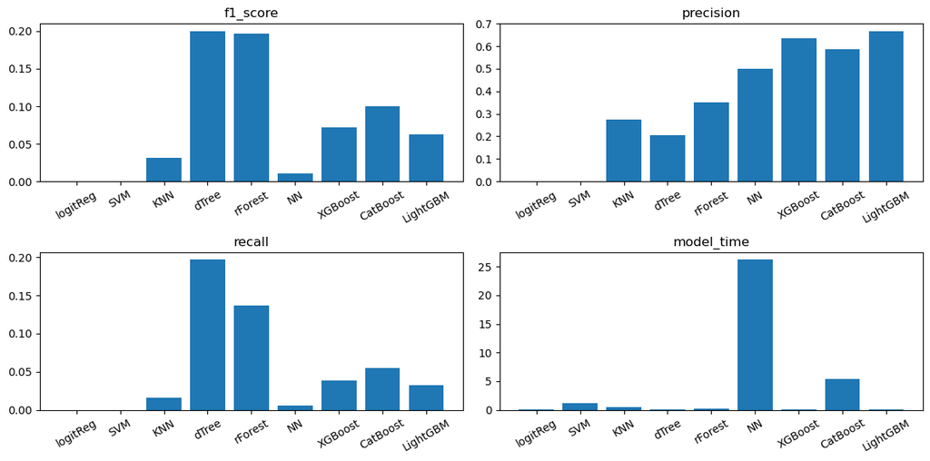

```python
# Evaluate models and visualize models performance
[resultTable, predValue] = modelEvaluation(
    models, X_train=X_train, y_train=y_train, X_test=X_test, y_test=y_test)
modelVisualization(resultTable)
```

*Main Findings:*

- The model with highest f1_score is the decision tree(`dTree`), but its precision is low.
- XGBoost, CatBoost and LightGBM have relatively high precision, but their recall is low.
- Overall, random forest (`rForest`) has a balanced performance.

## Hyperparameter tuning

```python
# Function to perform GridSearchCV fit
def bestModel(modelInfo, modelParam):
    modelName = modelInfo[0]
    model = modelInfo[1]
    timeBeg = time.time()
    theSearch = GridSearchCV(
        model,
        modelParam,
        scoring=["f1", "precision", "recall"],
        cv=5,
        refit="f1",
        n_jobs=-1,
    )
    modelObjects[modelName] = theSearch.fit(X_train, y_train)
    timeDur = time.time() - timeBeg
    modelObjects[modelName + "Time"] = timeDur
    return modelObjects
```

```python
modelObjects = {}
modelInfo = ("KNN", KNeighborsClassifier())
modelParam = {
    "n_neighbors": [3, 5, 7, 9, 11],
    "weights": ["uniform", "distance"],
    "algorithm": ["auto", "ball_tree", "kd_tree", "brute"],
}
bestModel(modelInfo, modelParam);
```

```python
modelInfo = ("dTree", DecisionTreeClassifier(random_state=8))
modelParam = {
    "max_depth": [None, 10, 20, 30, 40, 50],
    "min_samples_split": [2, 5, 8, 10, 15],
    "min_samples_leaf": [1, 2, 3, 4, 5],
}
bestModel(modelInfo, modelParam);
```

```python
modelInfo = ("rForest", RandomForestClassifier(n_jobs=-1, random_state=8))
modelParam = {
    "n_estimators": [300, 500],
    "max_depth": [None, 10, 30, 50],
    "max_features": ["auto", "sqrt", "log2"],
}
bestModel(modelInfo, modelParam);
```

```python
modelInfo = ("NN", MLPClassifier(random_state=8))
modelParam = {
    "hidden_layer_sizes": [(100,), (50, 30)],
    "activation": ["identity", "logistic", "tanh", "relu"],
    "solver": ["lbfgs", "sgd", "adam"],
    "max_iter": [500],
}
bestModel(modelInfo, modelParam);
```

```python
modelInfo = ("XGBoost", XGBClassifier())
modelParam = {
    "min_child_weight": [1, 2, 3, 4, 5],
    "learning_rate": [0.001, 0.01, 0.1, 0.2, 0.3, 0.5],
    "n_estimators": [1500, 1800, 2000],
}
bestModel(modelInfo, modelParam);
```

```python
modelInfo = ("CatBoost", CatBoostClassifier(random_seed=8, verbose=False))
modelParam = {
    "iterations": [100, 300, 500],
    "learning_rate": [0.001, 0.01, 0.1, 0.3],
    "depth": [4, 6, 8, 10]
}
bestModel(modelInfo, modelParam);
```

```python
modelInfo = ("LightGBM", LGBMClassifier(verbose=-1))
modelParam = {
    "n_estimators": [1500, 1800, 2000],
    "learning_rate": [0.001, 0.01, 0.1, 0.2, 0.3, 0.5]
}
bestModel(modelInfo, modelParam);
```

```python
# Function to extract scores from the GridSearchCV fit object
def estimationResult(modelObjects):
    theBestEstimators = {}
    theBestParameters = {}
    estimationCompare = {}
    modelNames = [v for v in modelObjects.keys() if not all(s in v for s in "Time")]
    for modelName in modelNames:
        cv_results = pd.DataFrame(modelObjects[modelName].cv_results_)
        best_estimator_results = cv_results.iloc[cv_results["mean_test_f1"].idxmax(), :]
        f1 = best_estimator_results.mean_test_f1
        precision = best_estimator_results.mean_test_precision
        recall = best_estimator_results.mean_test_recall
        timeDur = modelObjects[modelName + "Time"]
        estimationCompare.update({modelName: [f1, precision, recall, timeDur]})

        theBestEstimators[modelName] = modelObjects[modelName].best_estimator_
        theBestParameters[modelName] = modelObjects[modelName].best_params_

    estimationCompare = pd.DataFrame(estimationCompare)
    estimationCompare.index = [
        "mean_f1_score",
        "mean_precision",
        "mean_recall",
        "mean_model_time",
    ]

    return theBestEstimators, theBestParameters, estimationCompare
```

```python
# Call the function on our models
[theBestEstimators, theBestParameters, estimationCompare] = estimationResult(modelObjects)
print("The best parameters: >> \n")
display(theBestParameters)
print("")
print("The best parameters performance: >> \n")
display(estimationCompare)
```

```
The best parameters: >>
```

```
{'KNN': {'algorithm': 'auto', 'n_neighbors': 3, 'weights': 'distance'},
 'dTree': {'max_depth': 30, 'min_samples_leaf': 1, 'min_samples_split': 2},
 'rForest': {'max_depth': None, 'max_features': 'log2', 'n_estimators': 300},
 'NN': {'activation': 'tanh',
  'hidden_layer_sizes': (50, 30),
  'max_iter': 500,
  'solver': 'adam'},
 'XGBoost': {'learning_rate': 0.5,
  'min_child_weight': 2,
  'n_estimators': 1800},
 'CatBoost': {'depth': 10, 'iterations': 500, 'learning_rate': 0.3},
 'LightGBM': {'learning_rate': 0.1, 'n_estimators': 1500}}
```

```
The best parameters performance: >>
```

|  | KNN | dTree | rForest | NN | XGBoost | CatBoost | LightGBM |
| --- | --- | --- | --- | --- | --- | --- | --- |
| mean_f1_score | 0.150449 | 0.166676 | 0.183797 | 0.093761 | 0.205585 | 0.208490 | 0.193177 |
| mean_precision | 0.259257 | 0.172496 | 0.356108 | 0.248469 | 0.366184 | 0.395618 | 0.357756 |
| mean_recall | 0.108044 | 0.164295 | 0.124514 | 0.058769 | 0.145609 | 0.143228 | 0.133844 |
| mean_model_time | 14.901885 | 5.263868 | 27.629544 | 151.495494 | 113.399137 | 195.349832 | 140.571942 |

# Model selection and final results

```python
# Predict on test data
resultTable = {}
predValue = {}

for modelName in theBestParameters.keys():
    y_pred = theBestEstimators[modelName].predict(X_test)
    f1 = metrics.f1_score(y_test, y_pred)
    precision = metrics.precision_score(y_test, y_pred)
    recall = metrics.recall_score(y_test, y_pred)

    resultTable.update({modelName: [f1, precision, recall]})
    predValue.update({modelName: y_pred})

resultTable = pd.DataFrame(resultTable)
resultTable.index = ["f1_score", "precision", "recall"]
predValue = pd.DataFrame(predValue)
predValue["actual"] = y_test.reset_index(drop=True)

print("models performance >>")
display(resultTable.head())
print("")
print("predictions overview >>")
display(predValue.head())
```

```
models performance >>
```

|  | KNN | dTree | rForest | NN | XGBoost | CatBoost | LightGBM |
| --- | --- | --- | --- | --- | --- | --- | --- |
| f1_score | 0.129278 | 0.186441 | 0.196078 | 0.077670 | 0.200000 | 0.199203 | 0.170040 |
| precision | 0.212500 | 0.192982 | 0.347222 | 0.347826 | 0.310345 | 0.367647 | 0.328125 |
| recall | 0.092896 | 0.180328 | 0.136612 | 0.043716 | 0.147541 | 0.136612 | 0.114754 |

```
predictions overview >>
```

|  | KNN | dTree | rForest | NN | XGBoost | CatBoost | LightGBM | actual |
| --- | --- | --- | --- | --- | --- | --- | --- | --- |
| 0 | 0 | 0 | 0 | 0 | 0 | 0 | 0 | 0 |
| 1 | 0 | 0 | 0 | 0 | 0 | 0 | 0 | 0 |
| 2 | 0 | 0 | 0 | 0 | 0 | 0 | 0 | 0 |
| 3 | 0 | 0 | 0 | 0 | 0 | 0 | 0 | 0 |
| 4 | 0 | 0 | 0 | 0 | 0 | 0 | 0 | 0 |

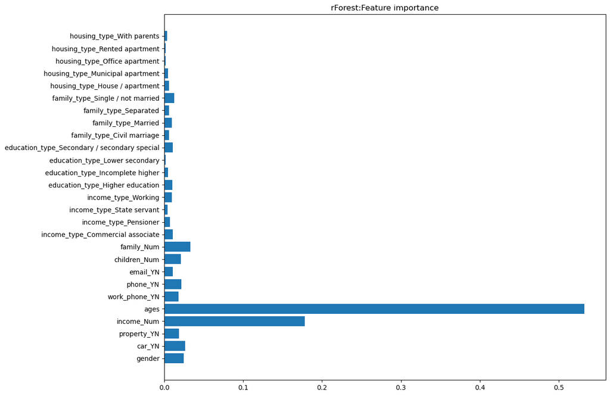

```python
# Feature importance of the model
impt = theBestEstimators["rForest"].feature_importances_
plt.subplots(figsize=(12, 10))
plt.barh(X_test.columns, impt)
plt.title("rForest:Feature importance")
plt.show()
```

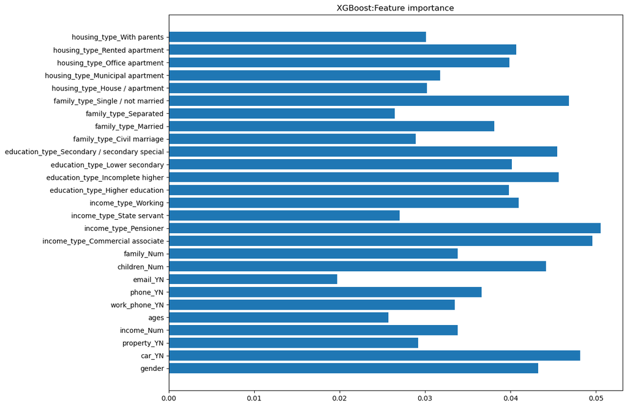

```python
# Feature importance of the model
impt = theBestEstimators["XGBoost"].feature_importances_
plt.subplots(figsize=(12, 10))
plt.barh(X_test.columns, impt)
plt.title("XGBoost:Feature importance")
plt.show()
```

```python
# Compute IV for all features
features = X_train.columns
target = y_train
IV = []
for feature in features:
    if feature not in ["ages", "income_Num", "family_Num", "children_Num"]:
        df_woe_iv = (
            pd.crosstab(X_train[feature], target, normalize="columns")
            .assign(woe=lambda x: np.log(x[1] / x[0]))
            .assign(iv=lambda x: (x["woe"] * (x[1] - x[0])))
        )
        df_woe_iv = df_woe_iv.replace({"woe": {np.inf: 0, -np.inf: 0}})
        df_woe_iv = df_woe_iv.replace({"iv": {np.inf: 0, -np.inf: 0}})
        df_woe_iv["iv_sum"] = df_woe_iv.iv.sum()
        IV.append(df_woe_iv["iv_sum"][0])
    else:
        IV.append(np.nan)
IV = pd.DataFrame(IV, features, columns=["iv"])
IV["power"] = IV["iv"] > 0.02
display(IV)
```

|  | iv | power |
| --- | --- | --- |
| gender | 0.003613 | False |
| car_YN | 0.000336 | False |
| property_YN | 0.029718 | True |
| income_Num | NaN | False |
| ages | NaN | False |
| work_phone_YN | 0.001199 | False |
| phone_YN | 0.001532 | False |
| email_YN | 0.003039 | False |
| children_Num | NaN | False |
| family_Num | NaN | False |
| income_type_Commercial associate | 0.000005 | False |
| income_type_Pensioner | 0.024034 | True |
| income_type_State servant | 0.011245 | False |
| income_type_Working | 0.005035 | False |
| education_type_Higher education | 0.000108 | False |
| education_type_Incomplete higher | 0.000418 | False |
| education_type_Lower secondary | 0.001052 | False |
| education_type_Secondary / secondary special | 0.000573 | False |
| family_type_Civil marriage | 0.001557 | False |
| family_type_Married | 0.009663 | False |
| family_type_Separated | 0.000234 | False |
| family_type_Single / not married | 0.004036 | False |
| housing_type_House / apartment | 0.003511 | False |
| housing_type_Municipal apartment | 0.016113 | False |
| housing_type_Office apartment | 0.008691 | False |
| housing_type_Rented apartment | 0.000817 | False |
| housing_type_With parents | 0.004526 | False |

**`The Information Value (IV) is a metric that assesses a variable's predictive power.`**

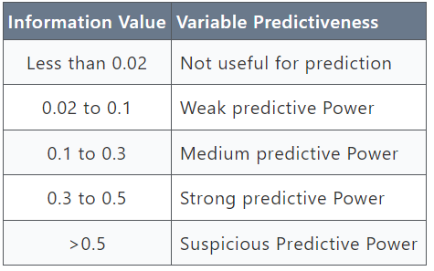

Source: https://www.listendata.com/2015/03/weight-of-evidence-woe-and-information.html

*Main Findings:*

- In conclusion, Random forest and XGBoost perform relatively well in prediction and have similar performance; however, the predictive power of these models is not particularly high.
- According to the information value, most of the variables are not useful for prediction.

# Basic steps to curb imbalance in data

```python
# Perform over-sampling using SMOTE
from imblearn.over_sampling import SMOTE
smt = SMOTE(random_state=8,sampling_strategy=0.5)
X_resampled, y_resampled = smt.fit_resample(X_train, y_train)
y_train.value_counts(), y_resampled.value_counts()
```

```
(default
 0    24713
 1      426
 Name: count, dtype: int64,
 default
 0    24713
 1    12356
 Name: count, dtype: int64)
```

```
models performance >>
```

|  | logitReg | SVM | KNN | dTree | rForest | NN | XGBoost | CatBoost | LightGBM |
| --- | --- | --- | --- | --- | --- | --- | --- | --- | --- |
| f1_score | 0.033473 | 0.010695 | 0.107503 | 0.156934 | 0.214085 | 0.096154 | 0.147059 | 0.181818 | 0.121065 |
| precision | 0.022472 | 0.250000 | 0.067606 | 0.117808 | 0.220930 | 0.057232 | 0.133333 | 0.213235 | 0.108696 |
| recall | 0.065574 | 0.005464 | 0.262295 | 0.234973 | 0.207650 | 0.300546 | 0.163934 | 0.158470 | 0.136612 |
| model_time | 0.188752 | 34.970771 | 0.437423 | 0.109366 | 0.349961 | 49.583539 | 0.171879 | 10.366354 | 0.124998 |

```
predictions overview >>
```

|  | logitReg | SVM | KNN | dTree | rForest | NN | XGBoost | CatBoost | LightGBM | actual |
| --- | --- | --- | --- | --- | --- | --- | --- | --- | --- | --- |
| 0 | 0 | 0 | 0 | 0 | 0 | 0 | 0 | 0 | 0 | 0 |
| 1 | 0 | 0 | 0 | 0 | 0 | 0 | 0 | 0 | 0 | 0 |
| 2 | 0 | 0 | 0 | 0 | 0 | 0 | 0 | 0 | 0 | 0 |
| 3 | 0 | 0 | 0 | 0 | 0 | 0 | 0 | 0 | 0 | 0 |
| 4 | 0 | 0 | 0 | 0 | 0 | 1 | 0 | 0 | 0 | 0 |

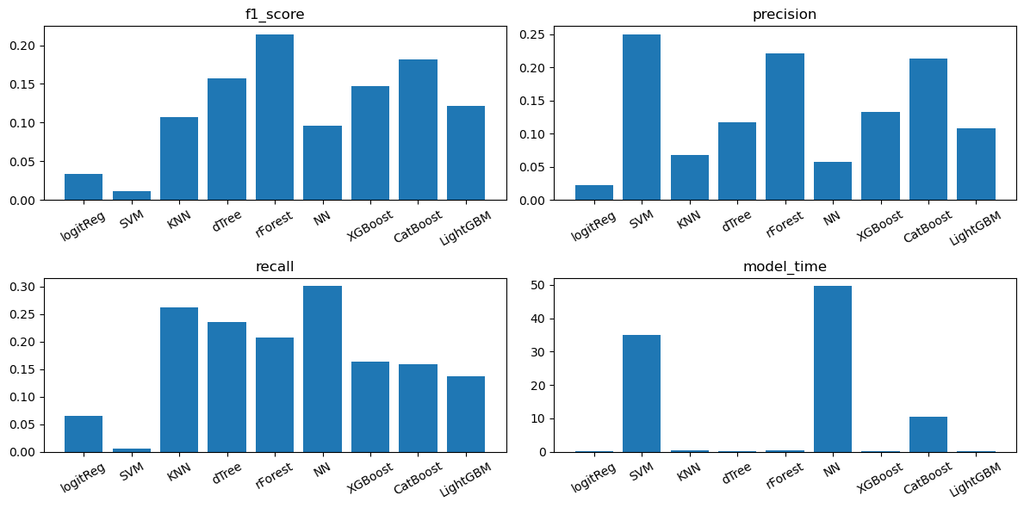

```python
# Estimation and prediction using resampled data
models = [
    ("logitReg", LogisticRegression()),
    ("SVM", SVC(random_state=8)),
    ("KNN", KNeighborsClassifier()),
    ("dTree", DecisionTreeClassifier(random_state=8)),
    ("rForest", RandomForestClassifier(n_jobs=-1, random_state=8)),
    ("NN", MLPClassifier(random_state=8)),
    ("XGBoost", XGBClassifier()),
    ("CatBoost", CatBoostClassifier(random_seed=8, verbose=False)),
    ("LightGBM", LGBMClassifier(verbose=-1)),
]

[resultTable, predValue] = modelEvaluation(
    models, X_train=X_resampled, y_train=y_resampled, X_test=X_test, y_test=y_test
)

modelVisualization(resultTable)
```

*Main Findings:*

- Compared with the initial estimation and prediction results, simple models using resampled data exhibit better performance.
- It is evident that the dataset is significantly imbalanced, necessitating further data collection and additional techniques to overcome problems caused by imbalanced datasets.